# Risk Factor Analysis

## Outcome Variable

**Outcome Variable:** ever_stunted

## Predictor Variables

**Intervention Variable:** perdiar6

**Adjustment Set:**

- arm
- sex
- W_mage
- meducyrs
- W_mhtcm
- W_mwtkg
- W_mbmi
- W_birthwt
- W_birthlen
- W_nrooms
- month
- brthmon
- impfloor
- impsan
- safeh20
- delta_W_mage
- delta_meducyrs
- delta_W_mhtcm
- delta_W_mwtkg
- delta_W_mbmi
- delta_W_birthwt
- delta_W_birthlen
- delta_W_nrooms
- delta_month
- delta_brthmon
- delta_impfloor
- delta_impsan
- delta_safeh20

## Stratifying Variables

The analysis was stratified on these variable(s):

- agecat
- studyid
- country

## Data Summary

| agecat | studyid | country | perdiar6 | ever_stunted | n_cell | n |
| --- | --- | --- | --- | --- | --- | --- |
| 0-24 months (no birth st.) | ki0047075b-MAL-ED | BANGLADESH | (0%, 5%] | 0 | 41 | 217 |
| 0-24 months (no birth st.) | ki0047075b-MAL-ED | BANGLADESH | (0%, 5%] | 1 | 44 | 217 |
| 0-24 months (no birth st.) | ki0047075b-MAL-ED | BANGLADESH | 0% | 0 | 36 | 217 |
| 0-24 months (no birth st.) | ki0047075b-MAL-ED | BANGLADESH | 0% | 1 | 36 | 217 |
| 0-24 months (no birth st.) | ki0047075b-MAL-ED | BANGLADESH | >5% | 0 | 27 | 217 |
| 0-24 months (no birth st.) | ki0047075b-MAL-ED | BANGLADESH | >5% | 1 | 33 | 217 |
| 0-24 months (no birth st.) | ki0047075b-MAL-ED | BRAZIL | (0%, 5%] | 0 | 12 | 208 |
| 0-24 months (no birth st.) | ki0047075b-MAL-ED | BRAZIL | (0%, 5%] | 1 | 2 | 208 |
| 0-24 months (no birth st.) | ki0047075b-MAL-ED | BRAZIL | 0% | 0 | 165 | 208 |
| 0-24 months (no birth st.) | ki0047075b-MAL-ED | BRAZIL | 0% | 1 | 27 | 208 |
| 0-24 months (no birth st.) | ki0047075b-MAL-ED | BRAZIL | >5% | 0 | 2 | 208 |
| 0-24 months (no birth st.) | ki0047075b-MAL-ED | BRAZIL | >5% | 1 | 0 | 208 |
| 0-24 months (no birth st.) | ki0047075b-MAL-ED | INDIA | (0%, 5%] | 0 | 54 | 209 |
| 0-24 months (no birth st.) | ki0047075b-MAL-ED | INDIA | (0%, 5%] | 1 | 52 | 209 |
| 0-24 months (no birth st.) | ki0047075b-MAL-ED | INDIA | 0% | 0 | 24 | 209 |
| 0-24 months (no birth st.) | ki0047075b-MAL-ED | INDIA | 0% | 1 | 25 | 209 |
| 0-24 months (no birth st.) | ki0047075b-MAL-ED | INDIA | >5% | 0 | 23 | 209 |
| 0-24 months (no birth st.) | ki0047075b-MAL-ED | INDIA | >5% | 1 | 31 | 209 |
| 0-24 months (no birth st.) | ki0047075b-MAL-ED | NEPAL | (0%, 5%] | 0 | 54 | 212 |
| 0-24 months (no birth st.) | ki0047075b-MAL-ED | NEPAL | (0%, 5%] | 1 | 14 | 212 |
| 0-24 months (no birth st.) | ki0047075b-MAL-ED | NEPAL | 0% | 0 | 54 | 212 |
| 0-24 months (no birth st.) | ki0047075b-MAL-ED | NEPAL | 0% | 1 | 20 | 212 |
| 0-24 months (no birth st.) | ki0047075b-MAL-ED | NEPAL | >5% | 0 | 49 | 212 |
| 0-24 months (no birth st.) | ki0047075b-MAL-ED | NEPAL | >5% | 1 | 21 | 212 |
| 0-24 months (no birth st.) | ki0047075b-MAL-ED | PERU | (0%, 5%] | 0 | 29 | 266 |
| 0-24 months (no birth st.) | ki0047075b-MAL-ED | PERU | (0%, 5%] | 1 | 51 | 266 |
| 0-24 months (no birth st.) | ki0047075b-MAL-ED | PERU | 0% | 0 | 37 | 266 |
| 0-24 months (no birth st.) | ki0047075b-MAL-ED | PERU | 0% | 1 | 40 | 266 |
| 0-24 months (no birth st.) | ki0047075b-MAL-ED | PERU | >5% | 0 | 49 | 266 |
| 0-24 months (no birth st.) | ki0047075b-MAL-ED | PERU | >5% | 1 | 60 | 266 |

[output cut: 258 more lines]

The following strata were considered:

- agecat: 0-24 months (no birth st.), studyid: ki0047075b-MAL-ED, country: BANGLADESH
- agecat: 0-24 months (no birth st.), studyid: ki0047075b-MAL-ED, country: BRAZIL
- agecat: 0-24 months (no birth st.), studyid: ki0047075b-MAL-ED, country: INDIA
- agecat: 0-24 months (no birth st.), studyid: ki0047075b-MAL-ED, country: NEPAL
- agecat: 0-24 months (no birth st.), studyid: ki0047075b-MAL-ED, country: PERU
- agecat: 0-24 months (no birth st.), studyid: ki0047075b-MAL-ED, country: SOUTH AFRICA
- agecat: 0-24 months (no birth st.), studyid: ki0047075b-MAL-ED, country: TANZANIA, UNITED REPUBLIC OF
- agecat: 0-24 months (no birth st.), studyid: ki1000109-ResPak, country: PAKISTAN
- agecat: 0-24 months (no birth st.), studyid: ki1017093-NIH-Birth, country: BANGLADESH
- agecat: 0-24 months (no birth st.), studyid: ki1017093b-PROVIDE, country: BANGLADESH
- agecat: 0-24 months (no birth st.), studyid: ki1017093c-NIH-Crypto, country: BANGLADESH
- agecat: 0-24 months (no birth st.), studyid: ki1114097-CMIN, country: BANGLADESH
- agecat: 0-24 months (no birth st.), studyid: ki1114097-CMIN, country: BRAZIL
- agecat: 0-24 months (no birth st.), studyid: ki1114097-CMIN, country: GUINEA-BISSAU
- agecat: 0-24 months (no birth st.), studyid: ki1114097-CMIN, country: PERU
- agecat: 0-24 months (no birth st.), studyid: ki1114097-CONTENT, country: PERU
- agecat: 0-6 months (no birth st.), studyid: ki0047075b-MAL-ED, country: BANGLADESH
- agecat: 0-6 months (no birth st.), studyid: ki0047075b-MAL-ED, country: BRAZIL
- agecat: 0-6 months (no birth st.), studyid: ki0047075b-MAL-ED, country: INDIA
- agecat: 0-6 months (no birth st.), studyid: ki0047075b-MAL-ED, country: NEPAL
- agecat: 0-6 months (no birth st.), studyid: ki0047075b-MAL-ED, country: PERU
- agecat: 0-6 months (no birth st.), studyid: ki0047075b-MAL-ED, country: SOUTH AFRICA
- agecat: 0-6 months (no birth st.), studyid: ki0047075b-MAL-ED, country: TANZANIA, UNITED REPUBLIC OF
- agecat: 0-6 months (no birth st.), studyid: ki1000109-ResPak, country: PAKISTAN
- agecat: 0-6 months (no birth st.), studyid: ki1017093-NIH-Birth, country: BANGLADESH
- agecat: 0-6 months (no birth st.), studyid: ki1017093b-PROVIDE, country: BANGLADESH
- agecat: 0-6 months (no birth st.), studyid: ki1017093c-NIH-Crypto, country: BANGLADESH
- agecat: 0-6 months (no birth st.), studyid: ki1114097-CMIN, country: BANGLADESH
- agecat: 0-6 months (no birth st.), studyid: ki1114097-CMIN, country: BRAZIL
- agecat: 0-6 months (no birth st.), studyid: ki1114097-CMIN, country: GUINEA-BISSAU
- agecat: 0-6 months (no birth st.), studyid: ki1114097-CMIN, country: PERU
- agecat: 0-6 months (no birth st.), studyid: ki1114097-CONTENT, country: PERU
- agecat: 6-24 months, studyid: ki0047075b-MAL-ED, country: BANGLADESH
- agecat: 6-24 months, studyid: ki0047075b-MAL-ED, country: BRAZIL
- agecat: 6-24 months, studyid: ki0047075b-MAL-ED, country: INDIA
- agecat: 6-24 months, studyid: ki0047075b-MAL-ED, country: NEPAL
- agecat: 6-24 months, studyid: ki0047075b-MAL-ED, country: PERU
- agecat: 6-24 months, studyid: ki0047075b-MAL-ED, country: SOUTH AFRICA
- agecat: 6-24 months, studyid: ki0047075b-MAL-ED, country: TANZANIA, UNITED REPUBLIC OF
- agecat: 6-24 months, studyid: ki1000109-ResPak, country: PAKISTAN
- agecat: 6-24 months, studyid: ki1017093-NIH-Birth, country: BANGLADESH
- agecat: 6-24 months, studyid: ki1017093b-PROVIDE, country: BANGLADESH
- agecat: 6-24 months, studyid: ki1017093c-NIH-Crypto, country: BANGLADESH
- agecat: 6-24 months, studyid: ki1114097-CMIN, country: BANGLADESH
- agecat: 6-24 months, studyid: ki1114097-CMIN, country: BRAZIL
- agecat: 6-24 months, studyid: ki1114097-CMIN, country: GUINEA-BISSAU
- agecat: 6-24 months, studyid: ki1114097-CMIN, country: PERU
- agecat: 6-24 months, studyid: ki1114097-CONTENT, country: PERU

### Dropped Strata

Some strata were dropped due to rare outcomes:

- agecat: 0-24 months (no birth st.), studyid: ki0047075b-MAL-ED, country: BRAZIL
- agecat: 0-24 months (no birth st.), studyid: ki0047075b-MAL-ED, country: SOUTH AFRICA
- agecat: 0-6 months (no birth st.), studyid: ki0047075b-MAL-ED, country: BRAZIL
- agecat: 0-6 months (no birth st.), studyid: ki0047075b-MAL-ED, country: NEPAL
- agecat: 0-6 months (no birth st.), studyid: ki0047075b-MAL-ED, country: SOUTH AFRICA
- agecat: 0-6 months (no birth st.), studyid: ki1114097-CMIN, country: BRAZIL
- agecat: 0-6 months (no birth st.), studyid: ki1114097-CMIN, country: GUINEA-BISSAU
- agecat: 0-6 months (no birth st.), studyid: ki1114097-CONTENT, country: PERU
- agecat: 6-24 months, studyid: ki0047075b-MAL-ED, country: BRAZIL
- agecat: 6-24 months, studyid: ki0047075b-MAL-ED, country: SOUTH AFRICA
- agecat: 6-24 months, studyid: ki1000109-ResPak, country: PAKISTAN
- agecat: 6-24 months, studyid: ki1114097-CONTENT, country: PERU

## Methods Detail

We’re interested in the causal parameters $E[Y_a]$ for all values of $a \in \mathcal{A}$. These parameters represent the mean outcome if, possibly contrary to fact, we intervened to set all units to have $A=a$. Under the randomization and positivity assumptions, these are identified by the statistical parameters $\psi_a=E_W[E_{Y|A,W}(Y|A=a,W)]$. In addition, we’re interested in the mean of $Y$, $E[Y]$ under no intervention (the observed mean). We will estimate these parameters by using SuperLearner to fit the relevant likelihood factors – $E_{Y|A,W}(Y|A=a,W)$ and $p(A=a|W)$, and then updating our likelihood fit using a joint TMLE.

For unadjusted analyses ($W=\{\}$), initial likelihoods were estimated using Lrnr_glm to estimate the simple $E(Y|A)$ and Lrnr_mean to estimate $p(A)$. For adjusted analyses, a small library containing Lrnr_glmnet, Lrnr_xgboost, and Lrnr_mean was used.

Having estimated these parameters, we will then use the delta method to estimate relative risks and attributable risks relative to a prespecified baseline level of $A$.

# Results Detail

## Results Plots

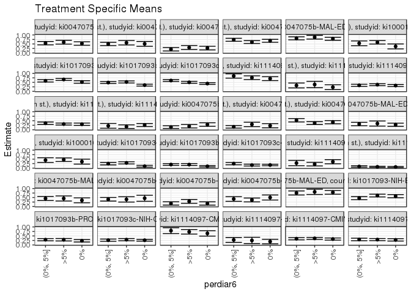

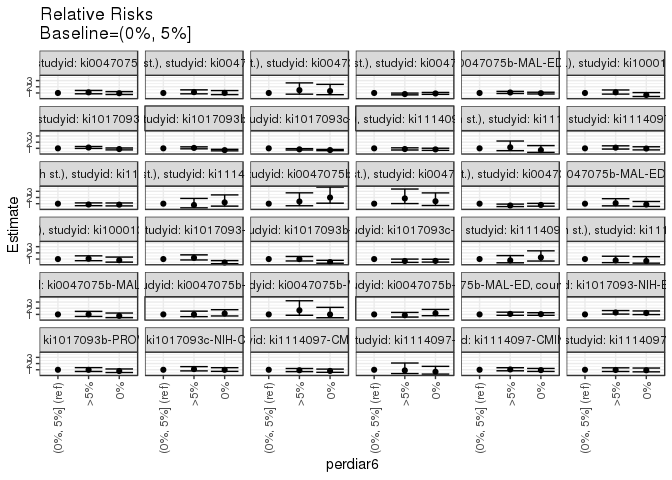

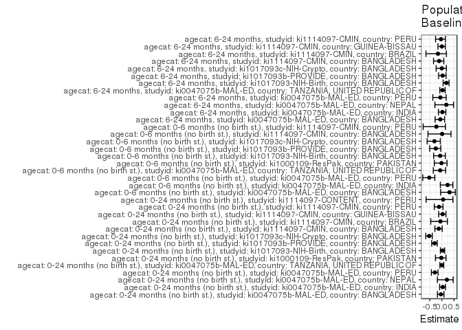

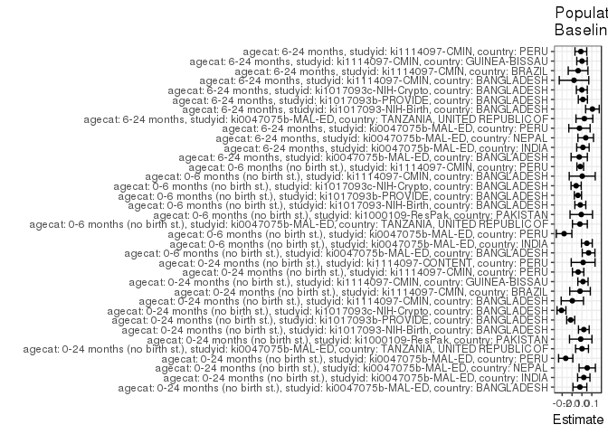

## Results Table

### Parameter: TSM

| agecat | studyid | country | intervention_level | baseline_level | estimate | ci_lower | ci_upper |
| --- | --- | --- | --- | --- | --- | --- | --- |
| 0-24 months (no birth st.) | ki0047075b-MAL-ED | BANGLADESH | (0%, 5%] | NA | 0.5413030 | 0.4463561 | 0.6362500 |
| 0-24 months (no birth st.) | ki0047075b-MAL-ED | BANGLADESH | 0% | NA | 0.5214677 | 0.4259764 | 0.6169590 |
| 0-24 months (no birth st.) | ki0047075b-MAL-ED | BANGLADESH | >5% | NA | 0.5970888 | 0.4897375 | 0.7044401 |
| 0-24 months (no birth st.) | ki0047075b-MAL-ED | INDIA | (0%, 5%] | NA | 0.4979846 | 0.4053283 | 0.5906409 |
| 0-24 months (no birth st.) | ki0047075b-MAL-ED | INDIA | 0% | NA | 0.5047475 | 0.3707270 | 0.6387679 |
| 0-24 months (no birth st.) | ki0047075b-MAL-ED | INDIA | >5% | NA | 0.5657153 | 0.4419046 | 0.6895260 |
| 0-24 months (no birth st.) | ki0047075b-MAL-ED | NEPAL | (0%, 5%] | NA | 0.2058797 | 0.1095491 | 0.3022102 |
| 0-24 months (no birth st.) | ki0047075b-MAL-ED | NEPAL | 0% | NA | 0.2702688 | 0.1688434 | 0.3716941 |
| 0-24 months (no birth st.) | ki0047075b-MAL-ED | NEPAL | >5% | NA | 0.3000050 | 0.1924025 | 0.4076076 |
| 0-24 months (no birth st.) | ki0047075b-MAL-ED | PERU | (0%, 5%] | NA | 0.7316290 | 0.6485604 | 0.8146976 |
| 0-24 months (no birth st.) | ki0047075b-MAL-ED | PERU | 0% | NA | 0.6740398 | 0.5917642 | 0.7563154 |
| 0-24 months (no birth st.) | ki0047075b-MAL-ED | PERU | >5% | NA | 0.6040166 | 0.5239814 | 0.6840517 |
| 0-24 months (no birth st.) | ki0047075b-MAL-ED | TANZANIA, UNITED REPUBLIC OF | (0%, 5%] | NA | 0.8117647 | 0.7284737 | 0.8950557 |
| 0-24 months (no birth st.) | ki0047075b-MAL-ED | TANZANIA, UNITED REPUBLIC OF | 0% | NA | 0.7872340 | 0.7043099 | 0.8701582 |
| 0-24 months (no birth st.) | ki0047075b-MAL-ED | TANZANIA, UNITED REPUBLIC OF | >5% | NA | 0.8750000 | 0.7722762 | 0.9777238 |
| 0-24 months (no birth st.) | ki1000109-ResPak | PAKISTAN | (0%, 5%] | NA | 0.5345877 | 0.4020008 | 0.6671747 |
| 0-24 months (no birth st.) | ki1000109-ResPak | PAKISTAN | 0% | NA | 0.3623679 | 0.2248858 | 0.4998499 |
| 0-24 months (no birth st.) | ki1000109-ResPak | PAKISTAN | >5% | NA | 0.5910055 | 0.4943030 | 0.6877081 |
| 0-24 months (no birth st.) | ki1017093-NIH-Birth | BANGLADESH | (0%, 5%] | NA | 0.5849536 | 0.5178731 | 0.6520340 |
| 0-24 months (no birth st.) | ki1017093-NIH-Birth | BANGLADESH | 0% | NA | 0.5184824 | 0.4474163 | 0.5895485 |
| 0-24 months (no birth st.) | ki1017093-NIH-Birth | BANGLADESH | >5% | NA | 0.6596115 | 0.6036089 | 0.7156140 |
| 0-24 months (no birth st.) | ki1017093b-PROVIDE | BANGLADESH | (0%, 5%] | NA | 0.4888773 | 0.4348040 | 0.5429506 |
| 0-24 months (no birth st.) | ki1017093b-PROVIDE | BANGLADESH | 0% | NA | 0.3456924 | 0.2935245 | 0.3978603 |
| 0-24 months (no birth st.) | ki1017093b-PROVIDE | BANGLADESH | >5% | NA | 0.5213634 | 0.4629039 | 0.5798228 |
| 0-24 months (no birth st.) | ki1017093c-NIH-Crypto | BANGLADESH | (0%, 5%] | NA | 0.6004205 | 0.5480848 | 0.6527562 |
| 0-24 months (no birth st.) | ki1017093c-NIH-Crypto | BANGLADESH | 0% | NA | 0.4317203 | 0.3849418 | 0.4784987 |
| 0-24 months (no birth st.) | ki1017093c-NIH-Crypto | BANGLADESH | >5% | NA | 0.5019378 | 0.4466105 | 0.5572650 |
| 0-24 months (no birth st.) | ki1114097-CMIN | BANGLADESH | (0%, 5%] | NA | 0.8529412 | 0.7335396 | 0.9723428 |
| 0-24 months (no birth st.) | ki1114097-CMIN | BANGLADESH | 0% | NA | 0.7058824 | 0.5972606 | 0.8145041 |
| 0-24 months (no birth st.) | ki1114097-CMIN | BANGLADESH | >5% | NA | 0.7575758 | 0.6538770 | 0.8612745 |

[output cut: 78 more lines]

### Parameter: E(Y)

| agecat | studyid | country | intervention_level | baseline_level | estimate | ci_lower | ci_upper |
| --- | --- | --- | --- | --- | --- | --- | --- |
| 0-24 months (no birth st.) | ki0047075b-MAL-ED | BANGLADESH | NA | NA | 0.5207373 | 0.4541154 | 0.5873593 |
| 0-24 months (no birth st.) | ki0047075b-MAL-ED | INDIA | NA | NA | 0.5167464 | 0.4488350 | 0.5846578 |
| 0-24 months (no birth st.) | ki0047075b-MAL-ED | NEPAL | NA | NA | 0.2594340 | 0.2002911 | 0.3185768 |
| 0-24 months (no birth st.) | ki0047075b-MAL-ED | PERU | NA | NA | 0.5676692 | 0.5080232 | 0.6273151 |
| 0-24 months (no birth st.) | ki0047075b-MAL-ED | TANZANIA, UNITED REPUBLIC OF | NA | NA | 0.8127854 | 0.7610035 | 0.8645672 |
| 0-24 months (no birth st.) | ki1000109-ResPak | PAKISTAN | NA | NA | 0.5223881 | 0.4531624 | 0.5916138 |
| 0-24 months (no birth st.) | ki1017093-NIH-Birth | BANGLADESH | NA | NA | 0.6041667 | 0.5624147 | 0.6459187 |
| 0-24 months (no birth st.) | ki1017093b-PROVIDE | BANGLADESH | NA | NA | 0.3753943 | 0.3376725 | 0.4131162 |
| 0-24 months (no birth st.) | ki1017093c-NIH-Crypto | BANGLADESH | NA | NA | 0.3935681 | 0.3560687 | 0.4310676 |
| 0-24 months (no birth st.) | ki1114097-CMIN | BANGLADESH | NA | NA | 0.7559524 | 0.6908084 | 0.8210964 |
| 0-24 months (no birth st.) | ki1114097-CMIN | BRAZIL | NA | NA | 0.3070175 | 0.2219720 | 0.3920631 |
| 0-24 months (no birth st.) | ki1114097-CMIN | GUINEA-BISSAU | NA | NA | 0.3443038 | 0.3111501 | 0.3774575 |
| 0-24 months (no birth st.) | ki1114097-CMIN | PERU | NA | NA | 0.3229167 | 0.2875370 | 0.3582963 |
| 0-24 months (no birth st.) | ki1114097-CONTENT | PERU | NA | NA | 0.2284264 | 0.1696529 | 0.2871999 |
| 0-6 months (no birth st.) | ki0047075b-MAL-ED | BANGLADESH | NA | NA | 0.2119816 | 0.1574763 | 0.2664868 |
| 0-6 months (no birth st.) | ki0047075b-MAL-ED | INDIA | NA | NA | 0.2105263 | 0.1551227 | 0.2659300 |
| 0-6 months (no birth st.) | ki0047075b-MAL-ED | PERU | NA | NA | 0.3458647 | 0.2885967 | 0.4031327 |
| 0-6 months (no birth st.) | ki0047075b-MAL-ED | TANZANIA, UNITED REPUBLIC OF | NA | NA | 0.2968037 | 0.2361590 | 0.3574483 |
| 0-6 months (no birth st.) | ki1000109-ResPak | PAKISTAN | NA | NA | 0.4378109 | 0.3690538 | 0.5065681 |
| 0-6 months (no birth st.) | ki1017093-NIH-Birth | BANGLADESH | NA | NA | 0.2291667 | 0.1932828 | 0.2650505 |
| 0-6 months (no birth st.) | ki1017093b-PROVIDE | BANGLADESH | NA | NA | 0.1593060 | 0.1307970 | 0.1878149 |
| 0-6 months (no birth st.) | ki1017093c-NIH-Crypto | BANGLADESH | NA | NA | 0.1898928 | 0.1597870 | 0.2199986 |
| 0-6 months (no birth st.) | ki1114097-CMIN | BANGLADESH | NA | NA | 0.2857143 | 0.2171983 | 0.3542303 |
| 0-6 months (no birth st.) | ki1114097-CMIN | PERU | NA | NA | 0.0744681 | 0.0543935 | 0.0945427 |
| 6-24 months | ki0047075b-MAL-ED | BANGLADESH | NA | NA | 0.4213836 | 0.3443902 | 0.4983771 |
| 6-24 months | ki0047075b-MAL-ED | INDIA | NA | NA | 0.4129032 | 0.3351414 | 0.4906651 |
| 6-24 months | ki0047075b-MAL-ED | NEPAL | NA | NA | 0.2102564 | 0.1529155 | 0.2675974 |
| 6-24 months | ki0047075b-MAL-ED | PERU | NA | NA | 0.3959732 | 0.3171819 | 0.4747644 |
| 6-24 months | ki0047075b-MAL-ED | TANZANIA, UNITED REPUBLIC OF | NA | NA | 0.7793103 | 0.7115754 | 0.8470453 |
| 6-24 months | ki1017093-NIH-Birth | BANGLADESH | NA | NA | 0.5739130 | 0.5216565 | 0.6261696 |
| 6-24 months | ki1017093b-PROVIDE | BANGLADESH | NA | NA | 0.2997812 | 0.2577294 | 0.3418330 |
| 6-24 months | ki1017093c-NIH-Crypto | BANGLADESH | NA | NA | 0.2628458 | 0.2244546 | 0.3012371 |
| 6-24 months | ki1114097-CMIN | BANGLADESH | NA | NA | 0.7117117 | 0.6270636 | 0.7963598 |
| 6-24 months | ki1114097-CMIN | BRAZIL | NA | NA | 0.2403846 | 0.1578607 | 0.3229085 |
| 6-24 months | ki1114097-CMIN | GUINEA-BISSAU | NA | NA | 0.3467532 | 0.3131150 | 0.3803915 |
| 6-24 months | ki1114097-CMIN | PERU | NA | NA | 0.2940171 | 0.2570662 | 0.3309680 |

### Parameter: RR

| agecat | studyid | country | intervention_level | baseline_level | estimate | ci_lower | ci_upper |
| --- | --- | --- | --- | --- | --- | --- | --- |
| 0-24 months (no birth st.) | ki0047075b-MAL-ED | BANGLADESH | (0%, 5%] | (0%, 5%] | 1.0000000 | 1.0000000 | 1.0000000 |
| 0-24 months (no birth st.) | ki0047075b-MAL-ED | BANGLADESH | 0% | (0%, 5%] | 0.9633563 | 0.7583787 | 1.2237360 |
| 0-24 months (no birth st.) | ki0047075b-MAL-ED | BANGLADESH | >5% | (0%, 5%] | 1.1030583 | 0.8652804 | 1.4061772 |
| 0-24 months (no birth st.) | ki0047075b-MAL-ED | INDIA | (0%, 5%] | (0%, 5%] | 1.0000000 | 1.0000000 | 1.0000000 |
| 0-24 months (no birth st.) | ki0047075b-MAL-ED | INDIA | 0% | (0%, 5%] | 1.0135805 | 0.7382528 | 1.3915903 |
| 0-24 months (no birth st.) | ki0047075b-MAL-ED | INDIA | >5% | (0%, 5%] | 1.1360096 | 0.8589954 | 1.5023571 |
| 0-24 months (no birth st.) | ki0047075b-MAL-ED | NEPAL | (0%, 5%] | (0%, 5%] | 1.0000000 | 1.0000000 | 1.0000000 |
| 0-24 months (no birth st.) | ki0047075b-MAL-ED | NEPAL | 0% | (0%, 5%] | 1.3127509 | 0.7205976 | 2.3915080 |
| 0-24 months (no birth st.) | ki0047075b-MAL-ED | NEPAL | >5% | (0%, 5%] | 1.4571861 | 0.8081253 | 2.6275519 |
| 0-24 months (no birth st.) | ki0047075b-MAL-ED | PERU | (0%, 5%] | (0%, 5%] | 1.0000000 | 1.0000000 | 1.0000000 |
| 0-24 months (no birth st.) | ki0047075b-MAL-ED | PERU | 0% | (0%, 5%] | 0.9212863 | 0.7808189 | 1.0870234 |
| 0-24 months (no birth st.) | ki0047075b-MAL-ED | PERU | >5% | (0%, 5%] | 0.8255777 | 0.6954422 | 0.9800649 |
| 0-24 months (no birth st.) | ki0047075b-MAL-ED | TANZANIA, UNITED REPUBLIC OF | (0%, 5%] | (0%, 5%] | 1.0000000 | 1.0000000 | 1.0000000 |
| 0-24 months (no birth st.) | ki0047075b-MAL-ED | TANZANIA, UNITED REPUBLIC OF | 0% | (0%, 5%] | 0.9697811 | 0.8371650 | 1.1234049 |
| 0-24 months (no birth st.) | ki0047075b-MAL-ED | TANZANIA, UNITED REPUBLIC OF | >5% | (0%, 5%] | 1.0778986 | 0.9222823 | 1.2597718 |
| 0-24 months (no birth st.) | ki1000109-ResPak | PAKISTAN | (0%, 5%] | (0%, 5%] | 1.0000000 | 1.0000000 | 1.0000000 |
| 0-24 months (no birth st.) | ki1000109-ResPak | PAKISTAN | 0% | (0%, 5%] | 0.6778455 | 0.4310197 | 1.0660174 |
| 0-24 months (no birth st.) | ki1000109-ResPak | PAKISTAN | >5% | (0%, 5%] | 1.1055352 | 0.8215804 | 1.4876306 |
| 0-24 months (no birth st.) | ki1017093-NIH-Birth | BANGLADESH | (0%, 5%] | (0%, 5%] | 1.0000000 | 1.0000000 | 1.0000000 |
| 0-24 months (no birth st.) | ki1017093-NIH-Birth | BANGLADESH | 0% | (0%, 5%] | 0.8863650 | 0.7459868 | 1.0531593 |
| 0-24 months (no birth st.) | ki1017093-NIH-Birth | BANGLADESH | >5% | (0%, 5%] | 1.1276305 | 0.9828103 | 1.2937904 |
| 0-24 months (no birth st.) | ki1017093b-PROVIDE | BANGLADESH | (0%, 5%] | (0%, 5%] | 1.0000000 | 1.0000000 | 1.0000000 |
| 0-24 months (no birth st.) | ki1017093b-PROVIDE | BANGLADESH | 0% | (0%, 5%] | 0.7071149 | 0.5925266 | 0.8438633 |
| 0-24 months (no birth st.) | ki1017093b-PROVIDE | BANGLADESH | >5% | (0%, 5%] | 1.0664503 | 0.9190248 | 1.2375251 |
| 0-24 months (no birth st.) | ki1017093c-NIH-Crypto | BANGLADESH | (0%, 5%] | (0%, 5%] | 1.0000000 | 1.0000000 | 1.0000000 |
| 0-24 months (no birth st.) | ki1017093c-NIH-Crypto | BANGLADESH | 0% | (0%, 5%] | 0.7190299 | 0.6322380 | 0.8177364 |
| 0-24 months (no birth st.) | ki1017093c-NIH-Crypto | BANGLADESH | >5% | (0%, 5%] | 0.8359771 | 0.7320830 | 0.9546154 |
| 0-24 months (no birth st.) | ki1114097-CMIN | BANGLADESH | (0%, 5%] | (0%, 5%] | 1.0000000 | 1.0000000 | 1.0000000 |
| 0-24 months (no birth st.) | ki1114097-CMIN | BANGLADESH | 0% | (0%, 5%] | 0.8275862 | 0.6721520 | 1.0189643 |
| 0-24 months (no birth st.) | ki1114097-CMIN | BANGLADESH | >5% | (0%, 5%] | 0.8881923 | 0.7302588 | 1.0802821 |

[output cut: 78 more lines]

### Parameter: PAR

| agecat | studyid | country | intervention_level | baseline_level | estimate | ci_lower | ci_upper |
| --- | --- | --- | --- | --- | --- | --- | --- |
| 0-24 months (no birth st.) | ki0047075b-MAL-ED | BANGLADESH | (0%, 5%] | NA | -0.0205657 | -0.0905164 | 0.0493850 |
| 0-24 months (no birth st.) | ki0047075b-MAL-ED | INDIA | (0%, 5%] | NA | 0.0187618 | -0.0436472 | 0.0811708 |
| 0-24 months (no birth st.) | ki0047075b-MAL-ED | NEPAL | (0%, 5%] | NA | 0.0535543 | -0.0290555 | 0.1361640 |
| 0-24 months (no birth st.) | ki0047075b-MAL-ED | PERU | (0%, 5%] | NA | -0.1639598 | -0.2359886 | -0.0919310 |
| 0-24 months (no birth st.) | ki0047075b-MAL-ED | TANZANIA, UNITED REPUBLIC OF | (0%, 5%] | NA | 0.0010207 | -0.0640452 | 0.0660865 |
| 0-24 months (no birth st.) | ki1000109-ResPak | PAKISTAN | (0%, 5%] | NA | -0.0121997 | -0.1256827 | 0.1012834 |
| 0-24 months (no birth st.) | ki1017093-NIH-Birth | BANGLADESH | (0%, 5%] | NA | 0.0192131 | -0.0347942 | 0.0732204 |
| 0-24 months (no birth st.) | ki1017093b-PROVIDE | BANGLADESH | (0%, 5%] | NA | -0.1134830 | -0.1539242 | -0.0730418 |
| 0-24 months (no birth st.) | ki1017093c-NIH-Crypto | BANGLADESH | (0%, 5%] | NA | -0.2068523 | -0.2517105 | -0.1619941 |
| 0-24 months (no birth st.) | ki1114097-CMIN | BANGLADESH | (0%, 5%] | NA | -0.0969888 | -0.2098156 | 0.0158380 |
| 0-24 months (no birth st.) | ki1114097-CMIN | BRAZIL | (0%, 5%] | NA | -0.0190694 | -0.1230196 | 0.0848808 |
| 0-24 months (no birth st.) | ki1114097-CMIN | GUINEA-BISSAU | (0%, 5%] | NA | 0.0104799 | -0.0412622 | 0.0622219 |
| 0-24 months (no birth st.) | ki1114097-CMIN | PERU | (0%, 5%] | NA | -0.0384034 | -0.0960155 | 0.0192086 |
| 0-24 months (no birth st.) | ki1114097-CONTENT | PERU | (0%, 5%] | NA | 0.0122102 | -0.1081884 | 0.1326088 |
| 0-6 months (no birth st.) | ki0047075b-MAL-ED | BANGLADESH | (0%, 5%] | NA | 0.0673560 | 0.0032104 | 0.1315016 |
| 0-6 months (no birth st.) | ki0047075b-MAL-ED | INDIA | (0%, 5%] | NA | 0.0500959 | -0.0044936 | 0.1046854 |
| 0-6 months (no birth st.) | ki0047075b-MAL-ED | PERU | (0%, 5%] | NA | -0.1802612 | -0.2588135 | -0.1017089 |
| 0-6 months (no birth st.) | ki0047075b-MAL-ED | TANZANIA, UNITED REPUBLIC OF | (0%, 5%] | NA | -0.0207157 | -0.0958557 | 0.0544244 |
| 0-6 months (no birth st.) | ki1000109-ResPak | PAKISTAN | (0%, 5%] | NA | -0.0066335 | -0.1201908 | 0.1069238 |
| 0-6 months (no birth st.) | ki1017093-NIH-Birth | BANGLADESH | (0%, 5%] | NA | -0.0163549 | -0.0716577 | 0.0389479 |
| 0-6 months (no birth st.) | ki1017093b-PROVIDE | BANGLADESH | (0%, 5%] | NA | -0.0404841 | -0.0768647 | -0.0041035 |
| 0-6 months (no birth st.) | ki1017093c-NIH-Crypto | BANGLADESH | (0%, 5%] | NA | -0.0586644 | -0.1101038 | -0.0072250 |
| 0-6 months (no birth st.) | ki1114097-CMIN | BANGLADESH | (0%, 5%] | NA | 0.0030044 | -0.1284725 | 0.1344814 |
| 0-6 months (no birth st.) | ki1114097-CMIN | PERU | (0%, 5%] | NA | -0.0169402 | -0.0508258 | 0.0169453 |
| 6-24 months | ki0047075b-MAL-ED | BANGLADESH | (0%, 5%] | NA | -0.0273428 | -0.1096791 | 0.0549935 |
| 6-24 months | ki0047075b-MAL-ED | INDIA | (0%, 5%] | NA | 0.0099473 | -0.0528512 | 0.0727458 |
| 6-24 months | ki0047075b-MAL-ED | NEPAL | (0%, 5%] | NA | 0.0384771 | -0.0402701 | 0.1172244 |
| 6-24 months | ki0047075b-MAL-ED | PERU | (0%, 5%] | NA | -0.0249763 | -0.1326603 | 0.0827076 |
| 6-24 months | ki0047075b-MAL-ED | TANZANIA, UNITED REPUBLIC OF | (0%, 5%] | NA | 0.0249244 | -0.0603766 | 0.1102254 |
| 6-24 months | ki1017093-NIH-Birth | BANGLADESH | (0%, 5%] | NA | 0.1060867 | 0.0370554 | 0.1751180 |
| 6-24 months | ki1017093b-PROVIDE | BANGLADESH | (0%, 5%] | NA | 0.0095319 | -0.0365970 | 0.0556609 |
| 6-24 months | ki1017093c-NIH-Crypto | BANGLADESH | (0%, 5%] | NA | -0.0009279 | -0.0562275 | 0.0543718 |
| 6-24 months | ki1114097-CMIN | BANGLADESH | (0%, 5%] | NA | -0.0799550 | -0.2292355 | 0.0693256 |
| 6-24 months | ki1114097-CMIN | BRAZIL | (0%, 5%] | NA | -0.0386852 | -0.1384409 | 0.0610706 |
| 6-24 months | ki1114097-CMIN | GUINEA-BISSAU | (0%, 5%] | NA | 0.0005370 | -0.0522341 | 0.0533082 |
| 6-24 months | ki1114097-CMIN | PERU | (0%, 5%] | NA | -0.0108630 | -0.0704437 | 0.0487177 |

### Parameter: PAF

| agecat | studyid | country | intervention_level | baseline_level | estimate | ci_lower | ci_upper |
| --- | --- | --- | --- | --- | --- | --- | --- |
| 0-24 months (no birth st.) | ki0047075b-MAL-ED | BANGLADESH | (0%, 5%] | NA | -0.0394935 | -0.1831925 | 0.0867533 |
| 0-24 months (no birth st.) | ki0047075b-MAL-ED | INDIA | (0%, 5%] | NA | 0.0363076 | -0.0925162 | 0.1499412 |
| 0-24 months (no birth st.) | ki0047075b-MAL-ED | NEPAL | (0%, 5%] | NA | 0.2064274 | -0.1830454 | 0.4676810 |
| 0-24 months (no birth st.) | ki0047075b-MAL-ED | PERU | (0%, 5%] | NA | -0.2888299 | -0.4329938 | -0.1591693 |
| 0-24 months (no birth st.) | ki0047075b-MAL-ED | TANZANIA, UNITED REPUBLIC OF | (0%, 5%] | NA | 0.0012558 | -0.0820932 | 0.0781847 |
| 0-24 months (no birth st.) | ki1000109-ResPak | PAKISTAN | (0%, 5%] | NA | -0.0233536 | -0.2654220 | 0.1724084 |
| 0-24 months (no birth st.) | ki1017093-NIH-Birth | BANGLADESH | (0%, 5%] | NA | 0.0318010 | -0.0617910 | 0.1171432 |
| 0-24 months (no birth st.) | ki1017093b-PROVIDE | BANGLADESH | (0%, 5%] | NA | -0.3023035 | -0.4205825 | -0.1938724 |
| 0-24 months (no birth st.) | ki1017093c-NIH-Crypto | BANGLADESH | (0%, 5%] | NA | -0.5255819 | -0.6650239 | -0.3978180 |
| 0-24 months (no birth st.) | ki1114097-CMIN | BANGLADESH | (0%, 5%] | NA | -0.1283001 | -0.2906531 | 0.0136302 |
| 0-24 months (no birth st.) | ki1114097-CMIN | BRAZIL | (0%, 5%] | NA | -0.0621118 | -0.4608456 | 0.2277887 |
| 0-24 months (no birth st.) | ki1114097-CMIN | GUINEA-BISSAU | (0%, 5%] | NA | 0.0304378 | -0.1321042 | 0.1696429 |
| 0-24 months (no birth st.) | ki1114097-CMIN | PERU | (0%, 5%] | NA | -0.1189268 | -0.3125303 | 0.0461195 |
| 0-24 months (no birth st.) | ki1114097-CONTENT | PERU | (0%, 5%] | NA | 0.0534535 | -0.6517332 | 0.4575696 |
| 0-6 months (no birth st.) | ki0047075b-MAL-ED | BANGLADESH | (0%, 5%] | NA | 0.3177446 | -0.0528422 | 0.5578896 |
| 0-6 months (no birth st.) | ki0047075b-MAL-ED | INDIA | (0%, 5%] | NA | 0.2379555 | -0.0645452 | 0.4544977 |
| 0-6 months (no birth st.) | ki0047075b-MAL-ED | PERU | (0%, 5%] | NA | -0.5211900 | -0.7913563 | -0.2917692 |
| 0-6 months (no birth st.) | ki0047075b-MAL-ED | TANZANIA, UNITED REPUBLIC OF | (0%, 5%] | NA | -0.0697959 | -0.3555654 | 0.1557300 |
| 0-6 months (no birth st.) | ki1000109-ResPak | PAKISTAN | (0%, 5%] | NA | -0.0151515 | -0.3106824 | 0.2137435 |
| 0-6 months (no birth st.) | ki1017093-NIH-Birth | BANGLADESH | (0%, 5%] | NA | -0.0713669 | -0.3419312 | 0.1446454 |
| 0-6 months (no birth st.) | ki1017093b-PROVIDE | BANGLADESH | (0%, 5%] | NA | -0.2541282 | -0.5054963 | -0.0447302 |
| 0-6 months (no birth st.) | ki1017093c-NIH-Crypto | BANGLADESH | (0%, 5%] | NA | -0.3089342 | -0.6095169 | -0.0644863 |
| 0-6 months (no birth st.) | ki1114097-CMIN | BANGLADESH | (0%, 5%] | NA | 0.0105154 | -0.5753685 | 0.3785075 |
| 0-6 months (no birth st.) | ki1114097-CMIN | PERU | (0%, 5%] | NA | -0.2274832 | -0.7735345 | 0.1504450 |
| 6-24 months | ki0047075b-MAL-ED | BANGLADESH | (0%, 5%] | NA | -0.0648881 | -0.2795834 | 0.1137845 |
| 6-24 months | ki0047075b-MAL-ED | INDIA | (0%, 5%] | NA | 0.0240911 | -0.1404879 | 0.1649203 |
| 6-24 months | ki0047075b-MAL-ED | NEPAL | (0%, 5%] | NA | 0.1830010 | -0.2891587 | 0.4822302 |
| 6-24 months | ki0047075b-MAL-ED | PERU | (0%, 5%] | NA | -0.0630758 | -0.3743111 | 0.1776751 |
| 6-24 months | ki0047075b-MAL-ED | TANZANIA, UNITED REPUBLIC OF | (0%, 5%] | NA | 0.0319826 | -0.0841333 | 0.1356619 |
| 6-24 months | ki1017093-NIH-Birth | BANGLADESH | (0%, 5%] | NA | 0.1848480 | 0.0541473 | 0.2974881 |
| 6-24 months | ki1017093b-PROVIDE | BANGLADESH | (0%, 5%] | NA | 0.0317963 | -0.1348619 | 0.1739801 |
| 6-24 months | ki1017093c-NIH-Crypto | BANGLADESH | (0%, 5%] | NA | -0.0035301 | -0.2376951 | 0.1863322 |
| 6-24 months | ki1114097-CMIN | BANGLADESH | (0%, 5%] | NA | -0.1123418 | -0.3454699 | 0.0803925 |
| 6-24 months | ki1114097-CMIN | BRAZIL | (0%, 5%] | NA | -0.1609302 | -0.6583752 | 0.1873015 |
| 6-24 months | ki1114097-CMIN | GUINEA-BISSAU | (0%, 5%] | NA | 0.0015488 | -0.1628480 | 0.1427041 |
| 6-24 months | ki1114097-CMIN | PERU | (0%, 5%] | NA | -0.0369468 | -0.2607379 | 0.1471195 |